# Part II - Prosper Loan Dataset Explanation

## by Amicah Maina

This explanation is based on exploration done on Loan Data from Prosper Loans, a Peer-to-Peer Lending company. **`The goal was to determine the best variables and fields that can be used to predict how the Borrower Rate(Loan Interest rate) is assigned to a loan listing`**

#### The prosper loans dataset contains over 100k observations with 81 variables with a date span of 9 years.

The main variables of interest I identified were:

- `CreditGrade`
- `LoanStatus`
- `BorrowerAPR`
- `LenderYield`
- `BorrowerState`
- `ProsperRatingNumeric`
- `ProsperScore`
- `LoanOriginalAmount`
- `Investors`
- `EmploymentStatus`
- `CreditScoreRangeUpper`
- `CreditScoreRangeLower`
- `EstimatedLoss`

Additional Variable I considered are:

- `DebtToIncomeRatio`
- `MonthlyLoanPayment`

The following insights were made on the data:

## Insight 1:

*In the investigation three variables showed a direct relation and positive impact on the BorrowerRate; `LenderYield,BorrowerAPR and EstimatedLoss`* As per the correlation of these variables with BorrowerRate an increase or decrease in any of these values would impact the BorrowerRate in the same nature.

##### The Visual below shows the relation between the three variables and BorrowerRate.

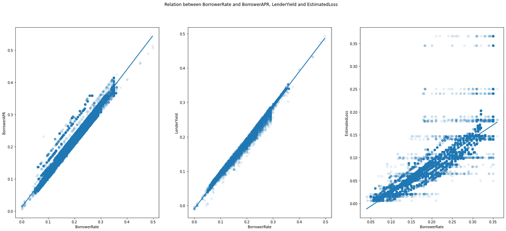

This prompted me to check on the data dictionary for the meaning of these variables.

- Estimated loss: is the estimated principal loss on charge-offs. Applicable for loans originated after July 2009.
- BorrowerAPR: The Borrower's Annual Percentage Rate (APR) for the loan. A calculated annual interest rate.
- Lender yield, is equal to the interest rate on the loan less the servicing fee.

The direct relationship between the BorrowerAPR and LenderYield with the Borrower Rate, gave me the incentive to eliminate them as they can be calculated from the Borrower Rate. However a deeper look was required for EstimatedLoss as this has relations on other variables on the dataset.

Two categorical variables show more direct effect on the EstimatedLoss and ultimately the Borrower Rate;

- ProsperScore, a custom risk score built using historical Prosper data. The score ranges from 1-11, with 11 being the best, or lowest risk score.
- ProsperRating, is a credit rating score assigned to loans during the time of listing

The figure below shows a low risk score or high rating will result to lower Estimated Loss.

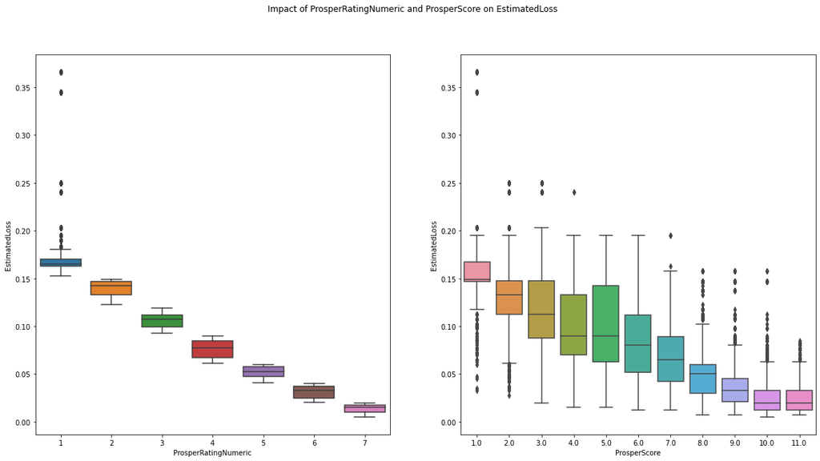

A scatterplot between EstimatedLoss and BorrowerRate with color palettes representing the two variables emphasized further the effect of the two categorical variables on the EstimatedLoss and BorrowerRate.

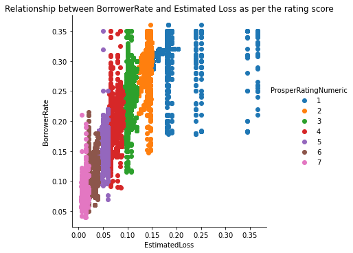

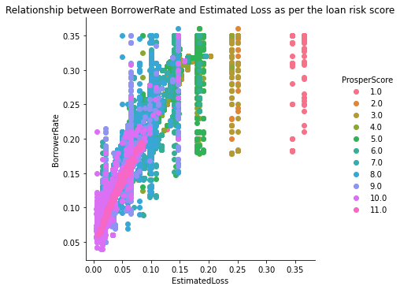

Due to the strong positive correlation between the Estimated Loss and Borrower Rate, the two categorical variables have a similary effect on the BorrowerRate.

##### In the visual below:

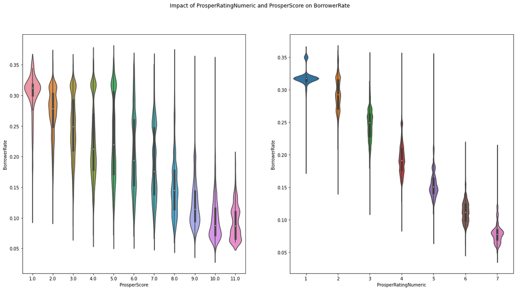

A combination of the two categorical variables( ProsperScore and ProsperRatingNumeric ) shows they strengthen each others impact of the BorrowerRate score.

##### The Visual below Shows the effect of ProsperScore and ProsperRatingNumeric on BorrowerRate:

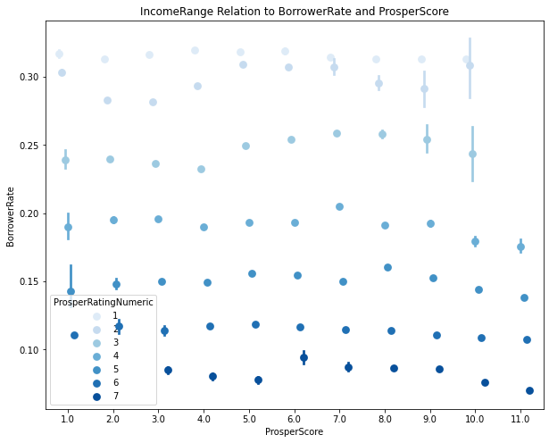

## Insight 2

A higher loan amount and a low risk score can result into a lower Borrower Rate. However, the Borrower Rate assigned does have a limit where at the lowest risk score, with the highest loan amount this limit cannot be surpassed.

#### The figure below shows the nature of the relationship between the LoanOriginalAmount and BorrowerRate variables:

Looking into the relationship between the two, we can observe a weak negative correlation between the two. It shows that an increase in the loan amount, can result into a slight decrease in the BorrowerRate.

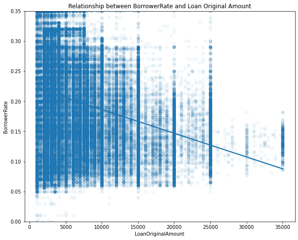

With just this weak relationship, it is not complete to assume the effect of the loan amount on the BorrowerRate can be used to predict the rate. Therefore a strengthening variable was used. In this case the Prosperscore variable showed more promise as it is based on the risk factor of the loan.

#### Visual below shows a relationship between ProsperScore, BorrowerRate and LoanOriginalAmount:

The variable ProsperScore strengthened this relationship to show us a more clear picture into the relation between the two variables.

The gradient of the lines on the graphs change gradually from a negative correlation at score 1 to a weak positive correlation at score 10 and 11. Showing a higher loan amount can result in a slight increase in the BorrowerRate, while the score is at its peak.

This behaviour indicates a limit to the lowest BorrowerRate that can be assigned to a Loan Listing despite it having the highest ProsperScore and higher LoanOriginalAmount. The graph on score 10 and 11 show a very weak postive correlation, which indicates that a low Borrower Rate is expected for a bigger LoanOriginalAmount despite the limit.

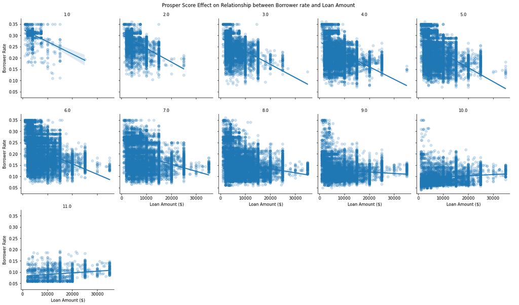

## Insight 3

The employment status of an individual and their Income Range can determine the average BorrowerRate assigned for their loan listing.

### Employment Status and Income Range effect on BorrowerRate

After determining the effect of loan amount prosper score and estimated loss. I sought to check on other variables that might affect the borrower rate assigned to a loan. Other such factors were the Employment status and Income Range of the Borrower Rate.

##### The figure below shows the relationship between the Income Range and Borrower Rate.

It shows on average the borrower rates that are adopted per income range. This can be said as the confidence intervals calculated.

As observed excluding the first peak at the start of the line indicating loans with no income ranges, the BorrowerRate reduces as the IncomeRange increases, with the lowest Borrower Rate being for the highest income range 100000+.

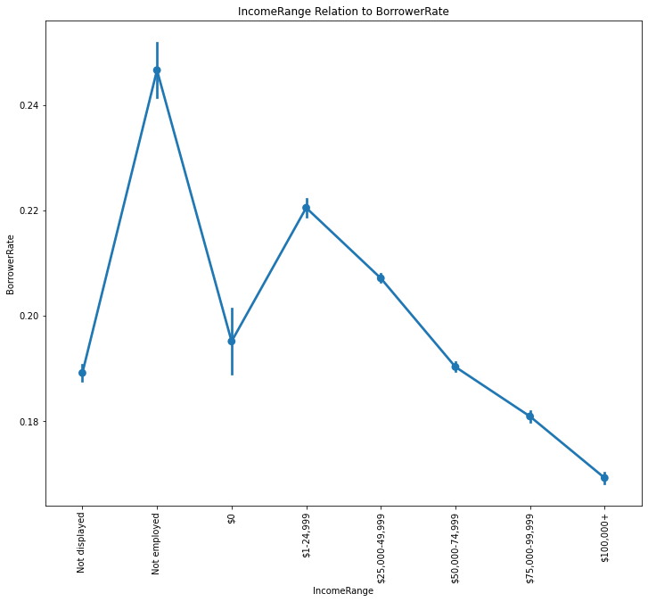

In the figure below, right skewed histograms can be observed for employment statuses, employed, other, self employed and Full time. This shows an inclination towards low borrower rates for these statuses, more so for employed and full time employment status. However, with the results it would be wrong to assume that the borrower rates are favorable for these two employment statuses, as these statuses have more value counts.

Therefore I was prompted to dig deeper into the distribution of the borrower rates in this employment status to realize the best way to predict the borrower rates.

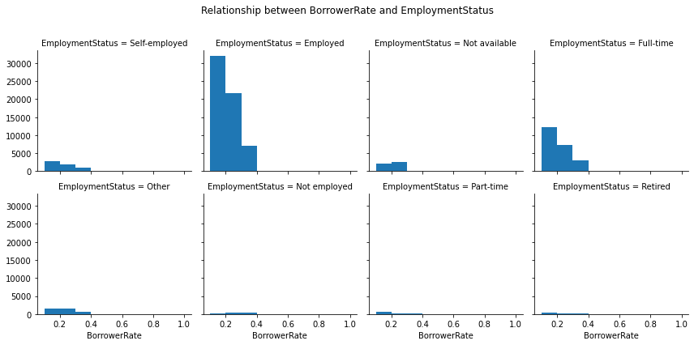

```
Employed         67322
Full-time        26355
Self-employed     6134
Not available     5347
Other             3806
Part-time         1088
Not employed       835
Retired            795
Name: EmploymentStatus, dtype: int64
```

The deeper investigation required a combination of the employment status with Income Range to give more insight.

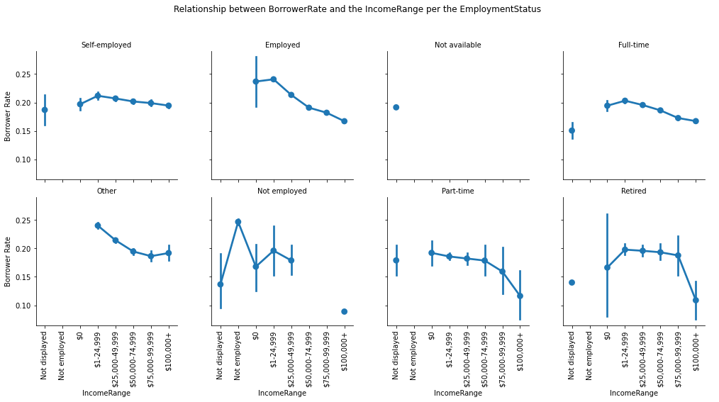